# HW 4: Dplyr

Data 180, Professor Kennedy

Tommy Eaton

eatot@dickinson.edu

October 31, 2023

**Due date:** October 26 beginning of class.

Let’s get some practice with **dplyr**! For this assignment, you will work with Mario Kart data! This data is made available as part of Tidy Tuesday. A codebook is available at https://github.com/rfordatascience/tidytuesday/tree/master/data/2021/2021-05-25.

[figure not shown]

Mario Kart

First, load in dplyr. Make sure to install dplyr (or tidyverse in general) first before calling the packages. (Notice the chunk below uses warning=FALSE and message=FALSE so that unnecessary messages won’t contaminate your md output!)

For the entire assignment, make sure to use dplyr functions only. (no base R!)

```r
library(dplyr)
records <- read.csv('https://raw.githubusercontent.com/rfordatascience/tidytuesday/master/data/2021/2021-05-25/records.csv')
head(records)
```

```
##           track      type shortcut  player system_played       date time_period
## 1 Luigi Raceway Three Lap       No   Salam          NTSC 1997-02-15   2M 12.99S
## 2 Luigi Raceway Three Lap       No   Booth          NTSC 1997-02-16    2M 9.99S
## 3 Luigi Raceway Three Lap       No   Salam          NTSC 1997-02-16    2M 8.99S
## 4 Luigi Raceway Three Lap       No   Salam          NTSC 1997-02-28    2M 6.99S
## 5 Luigi Raceway Three Lap       No Gregg G          NTSC 1997-03-07    2M 4.51S
## 6 Luigi Raceway Three Lap       No Rocky G          NTSC 1997-04-30    2M 2.89S
##     time record_duration
## 1 132.99               1
## 2 129.99               0
## 3 128.99              12
## 4 126.99               7
## 5 124.51              54
## 6 122.89               0
```

Here are the variables included and their meanings:

- `track`: Track name
- `type`: Single or three lap record
- `shortcut`: Shortcut or non-shortcut record
- `player`: Player’s name
- `system_played`: Used system (NTSC or PAL)
- `date`: World record date
- `time_period`: Time as hms period
- `time`: Time in seconds
- `record_duration`: Record duration in days

# Question 1

For the entire data, display the summary statistics (mean, median, mode, etc.) using the dplyr function `summary()` via pipe.

```r
summary_stat <- records %>%
  summarise_if(is.numeric,list(mean = ~mean(.), median = ~median(.), mode = ~mode(.)))
summary_stat
```

```
##   time_mean record_duration_mean time_median record_duration_median time_mode
## 1  90.62383             220.7506       86.19                     51   numeric
##   record_duration_mode
## 1              numeric
```

# Question 2

Return the count of cases where a record was broken in more than a year (365 days).

```r
count_records<- records %>%
  filter(record_duration > 365) %>%
  summarise(count = n_distinct(date))
count_records
```

```
##   count
## 1   293
```

# Question 3

Return name of the player, name of the track, record date, and record duration for the record that took the longest time to be broken.

```r
longest_record <- records %>%
  arrange(desc(record_duration)) %>%
  slice_head(n=1) %>%
  select(player, track, date, record_duration)
longest_record
```

```
##   player        track       date record_duration
## 1 Alex G Yoshi Valley 2010-11-27            3659
```

# Question 4

Return the mean record time (`time`) by each track. What is the name of the track with the fastest average record time? *Hint: you should use `group_by() and summarize()*

```r
average_times <- records %>%
  group_by(track) %>%
  summarise(mean_time = mean(time, na.rm = TRUE)) %>%
  arrange(mean_time) %>%
  slice_head(n = 1)
average_times
```

```
## # A tibble: 1 × 2
##   track         mean_time
##   <chr>             <dbl>
## 1 Mario Raceway      54.2
```

# Question 5

Let’s get the year from the `date` column and save it as a variable named `year`. You can use the function `substr(date, 1, 4)` which grabs the first 4 digits in the `date` column. Use this expression in `mutate()` to create a `year` column. (Don’t forget to save/overwrite the dataframe returned to the original one!)

```r
records <- records %>%
  mutate(year = substr(date, 1, 4))

head(records)
```

```
##           track      type shortcut  player system_played       date time_period
## 1 Luigi Raceway Three Lap       No   Salam          NTSC 1997-02-15   2M 12.99S
## 2 Luigi Raceway Three Lap       No   Booth          NTSC 1997-02-16    2M 9.99S
## 3 Luigi Raceway Three Lap       No   Salam          NTSC 1997-02-16    2M 8.99S
## 4 Luigi Raceway Three Lap       No   Salam          NTSC 1997-02-28    2M 6.99S
## 5 Luigi Raceway Three Lap       No Gregg G          NTSC 1997-03-07    2M 4.51S
## 6 Luigi Raceway Three Lap       No Rocky G          NTSC 1997-04-30    2M 2.89S
##     time record_duration year
## 1 132.99               1 1997
## 2 129.99               0 1997
## 3 128.99              12 1997
## 4 126.99               7 1997
## 5 124.51              54 1997
## 6 122.89               0 1997
```

# Question 6

Now get the average record time (`time`) by year.

```r
average_time_by_year <- records%>%
  group_by(year) %>%
  summarise(avg_time = mean(time, na.rm = TRUE))
head(average_time_by_year)
```

```
## # A tibble: 6 × 2
##   year  avg_time
##   <chr>    <dbl>
## 1 1997      93.3
## 2 1998      93.7
## 3 1999      87.7
## 4 2000      77.3
## 5 2001      92.8
## 6 2002      92.2
```

# Question 7

Continuing with your results in Question 6: Do you notice a trend across years? Are the record times getting faster, slower, or no clear pattern in time? Create a barplot where each year appears on the x axis (you can treat year as a categorical variable in this case) and y axis showing the mean record time in each year. Interpret your graph. *Hint: Use your code in Question 6, which returns the average record times by year, followed by `%>% ggplot(aes(year,mean)) + geom_bar(stat='identity')` Hint2: To make your figure wider, you can insert fig.width=10 inside the curly brackets at the beginning of your r code chunk below, as {r, fig.width=10} which I already did for you below,*

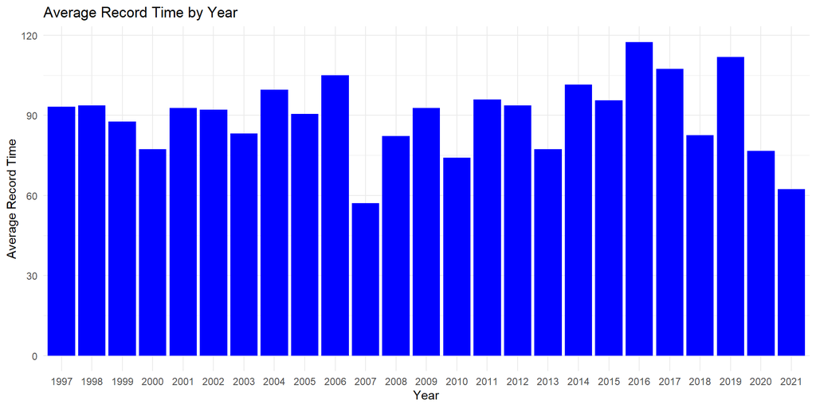

```r
library(ggplot2)
average_time_by_year <- records%>%
  group_by(year) %>%
  summarise(avg_time = mean(time, na.rm = TRUE))
average_time_by_year %>%
  ggplot(aes(x = year, y = avg_time)) +
  geom_bar(stat = 'identity', fill = "blue") +
  labs(title = "Average Record Time by Year",
       x = "Year",
       y = "Average Record Time") +
  theme_minimal()
```

# Question 8

Create two overlaid histograms by `type` on the same plot where each histogram shows the distribution of `time` for a given track `type`. Combine dplyr and ggplot2 to achieve this. How do record times compare between Single Lap and Three Lap tracks? Hint: use `records %>% dplyr functions %>% ggplot(., aes()) + type of ggplot plot` to combine dpylr with ggplot. Note that the dot inside `ggplot()` is a placeholder for `records`, as dplyr has already pulled `records` df at the beginning of the code (making it unnecessary to type it twice!)

Note: Set `alpha=.5` for transparency.

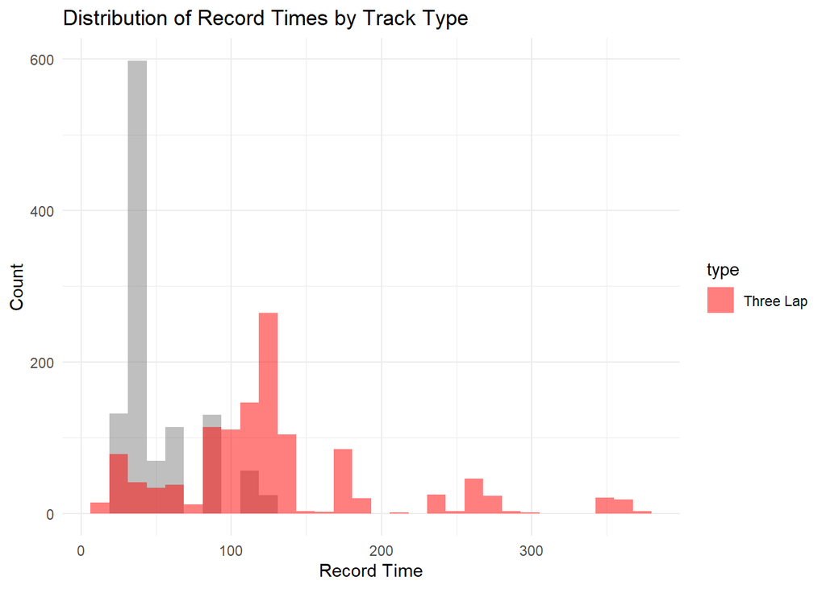

```r
records %>%
  ggplot(aes(x = time, fill = type)) +
  geom_histogram(alpha = 0.5, position = "identity", bins = 30) +
  labs(title = "Distribution of Record Times by Track Type",
       x = "Record Time",
       y = "Count") +
  scale_fill_manual(values = c("Single" = "blue", "Three Lap" = "red")) +
  theme_minimal()
```

# Question 9

Three Lap time reports the total time spent finishing three laps in total, as opposed to finishing a single lap. Let’s divide all time observations with `type=="Three Lap"` by 3 to check whether **per lap** performance declines across Three Lap vs. Single Lap. Generate a new variable named `time_per` which is the time spent per round, and create two overlaid histograms of `type_per` by `type`. Hint: Use `mutate()`, and inside `mutate()` use `ifelse()` function to conditionally replace rows: e.g.., `ifelse(type=="Three Lap",time/3,time)` which divides `time` by three only if `type=="Three Lap"`.

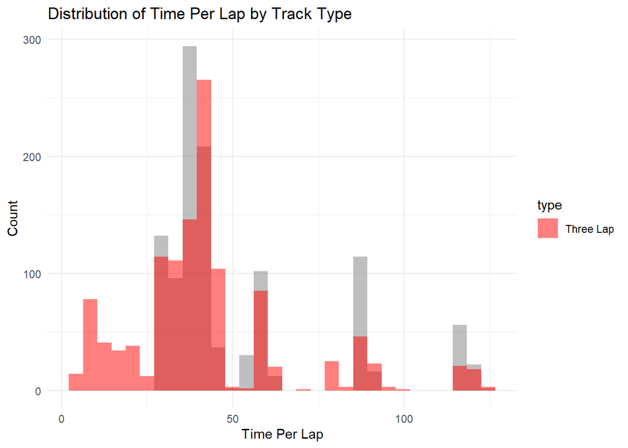

```r
records <- records%>%
  mutate(time_per = ifelse(type == "Three Lap", time/3, time))
records %>%
  ggplot(aes(x = time_per, fill = type)) +  geom_histogram(alpha = 0.5, position = "identity", bins = 30) +
  labs(title = "Distribution of Time Per Lap by Track Type",
       x = "Time Per Lap",
       y = "Count") +
  scale_fill_manual(values = c("Single" = "blue", "Three Lap" = "red")) +
  theme_minimal()
```

# Question 10 There appears to be recent discoveries of shortcuts within some of the tracks causing a number of extraordinarily fast records set in `Three Lap` tracks (Have you noticed this in your graph in Question 9?). Replicate your histogram in Question 9 with `shortcut=="No"` filter.

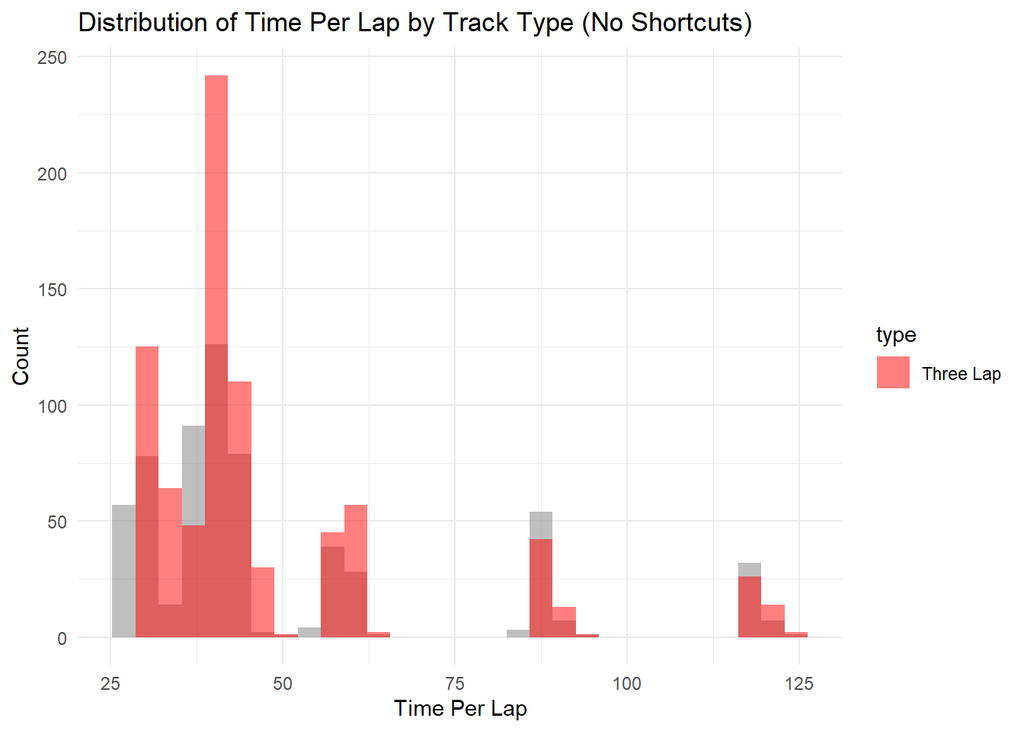

```r
records %>%
  filter(shortcut == "No") %>%
  ggplot(aes(x = time_per, fill = type)) +
  geom_histogram(alpha = 0.5, position = "identity", bins = 30) +
  labs(title = "Distribution of Time Per Lap by Track Type (No Shortcuts)",
       x = "Time Per Lap",
       y = "Count") +
  scale_fill_manual(values = c("Single" = "blue", "Three Lap" = "red")) +
  theme_minimal()
```

# Question 11

Lastly, compare the mean `time` by `system_played`. Do you observe a difference across the two game systems? (Note: NTSC version of the game runs at 60 FPS (Frames Per Second), and PAL runs at 50 FPS!) Does this appear to affect performance of records set?

```r
mean_time_by_system <- records%>%
  group_by(system_played) %>%
  summarise(avg_time = mean(time, na.rm = TRUE))
mean_time_by_system
```

```
## # A tibble: 2 × 2
##   system_played avg_time
##   <chr>            <dbl>
## 1 NTSC              79.9
## 2 PAL               95.2
```

You are done! 🏁 Don’t forget to commit and push your .Rmd file to your Github repository before the due date. (Well… the checkered flag emoji is now super relevant for this assignment!)